# Data Scientist Nanodegree

## Convolutional Neural Networks

## Project: Write an Algorithm for a Dog Identification App

This notebook walks you through one of the most popular Udacity projects across machine learning and artificial intellegence nanodegree programs. The goal is to classify images of dogs according to their breed.

If you are looking for a more guided capstone project related to deep learning and convolutional neural networks, this might be just it. Notice that even if you follow the notebook to creating your classifier, you must still create a blog post or deploy an application to fulfill the requirements of the capstone project.

Also notice, you may be able to use only parts of this notebook (for example certain coding portions or the data) without completing all parts and still meet all requirements of the capstone project.

In this notebook, some template code has already been provided for you, and you will need to implement additional functionality to successfully complete this project. You will not need to modify the included code beyond what is requested. Sections that begin with **'(IMPLEMENTATION)'** in the header indicate that the following block of code will require additional functionality which you must provide. Instructions will be provided for each section, and the specifics of the implementation are marked in the code block with a 'TODO' statement. Please be sure to read the instructions carefully!

In addition to implementing code, there will be questions that you must answer which relate to the project and your implementation. Each section where you will answer a question is preceded by a **'Question X'** header. Carefully read each question and provide thorough answers in the following text boxes that begin with **'Answer:'**. Your project submission will be evaluated based on your answers to each of the questions and the implementation you provide.

> **Note:** Code and Markdown cells can be executed using the **Shift + Enter** keyboard shortcut. Markdown cells can be edited by double-clicking the cell to enter edit mode.

The rubric contains *optional* "Stand Out Suggestions" for enhancing the project beyond the minimum requirements. If you decide to pursue the "Stand Out Suggestions", you should include the code in this IPython notebook.

### Why We're Here

In this notebook, you will make the first steps towards developing an algorithm that could be used as part of a mobile or web app. At the end of this project, your code will accept any user-supplied image as input. If a dog is detected in the image, it will provide an estimate of the dog's breed. If a human is detected, it will provide an estimate of the dog breed that is most resembling. The image below displays potential sample output of your finished project (... but we expect that each student's algorithm will behave differently!).

[figure not shown]

In this real-world setting, you will need to piece together a series of models to perform different tasks; for instance, the algorithm that detects humans in an image will be different from the CNN that infers dog breed. There are many points of possible failure, and no perfect algorithm exists. Your imperfect solution will nonetheless create a fun user experience!

### The Road Ahead

We break the notebook into separate steps. Feel free to use the links below to navigate the notebook.

## Step 0: Import Datasets

### Import Dog Dataset

In the code cell below, we import a dataset of dog images. We populate a few variables through the use of the `load_files` function from the scikit-learn library:

- `train_files`, `valid_files`, `test_files` - numpy arrays containing file paths to images
- `train_targets`, `valid_targets`, `test_targets` - numpy arrays containing onehot-encoded classification labels
- `dog_names` - list of string-valued dog breed names for translating labels

```python
## Import all packages
from sklearn.datasets import load_files
from keras.utils import np_utils
import numpy as np
from glob import glob
import cv2

import torch, os
import torch.nn as nn
from torchvision import models
from PIL import Image, ImageFile
from torchvision.transforms import transforms
from skimage import io
from torch.utils.data import DataLoader, dataset
from torchvision import datasets
ImageFile.LOAD_TRUNCATED_IMAGES = True
from model import Net
from torch import optim


pilTrans = transforms.ToPILImage()
import matplotlib.pyplot as plt
%matplotlib inline

device = 'cuda:0' if torch.cuda.is_available() else 'cpu'
print(device)
```

```
cuda:0
```

```python
# define function to load train, test, and validation datasets
def load_dataset(path):
    data = load_files(path)
    dog_files = np.array(data['filenames'])
    dog_targets = np_utils.to_categorical(np.array(data['target']), 133)
    return dog_files, dog_targets

# load train, test, and validation datasets
train_files, train_targets = load_dataset('./data/dogImages/train')
valid_files, valid_targets = load_dataset('./data/dogImages/valid')
test_files, test_targets = load_dataset('./data/dogImages/test')

# load list of dog names
dog_names = [item[20:-1] for item in sorted(glob("./data/dogImages/train/*/"))]

# print statistics about the dataset
print('There are %d total dog categories.' % len(dog_names))
print('There are %s total dog images.\n' % len(np.hstack([train_files, valid_files, test_files])))
print('There are %d training dog images.' % len(train_files))
print('There are %d validation dog images.' % len(valid_files))
print('There are %d test dog images.'% len(test_files))
```

```
There are 133 total dog categories.
There are 8351 total dog images.

There are 6680 training dog images.
There are 835 validation dog images.
There are 836 test dog images.
```

### Import Human Dataset

In the code cell below, we import a dataset of human images, where the file paths are stored in the numpy array `human_files`.

```python
import random
random.seed(8675309)

# load filenames in shuffled human dataset
human_files = np.array(glob("./data/lfw/*/*"))
random.shuffle(human_files)

# print statistics about the dataset
print('There are %d total human images.' % len(human_files))
```

```
There are 13233 total human images.
```

## Step 1: Detect Humans

We use OpenCV's implementation of [Haar feature-based cascade classifiers](http://docs.opencv.org/trunk/d7/d8b/tutorial_py_face_detection.html) to detect human faces in images. OpenCV provides many pre-trained face detectors, stored as XML files on [github](https://github.com/opencv/opencv/tree/master/data/haarcascades). We have downloaded one of these detectors and stored it in the `haarcascades` directory.

In the next code cell, we demonstrate how to use this detector to find human faces in a sample image.

```
Number of faces detected: 1
```

[figure not shown]

```python
# extract pre-trained face detector
face_cascade = cv2.CascadeClassifier('haarcascades/haarcascade_frontalface_alt.xml')

# load color (BGR) image
img = cv2.imread(human_files[4])
# convert BGR image to grayscale
gray = cv2.cvtColor(img, cv2.COLOR_BGR2GRAY)

# find faces in image
faces = face_cascade.detectMultiScale(gray)

# print number of faces detected in the image
print('Number of faces detected:', len(faces))

# get bounding box for each detected face
for (x,y,w,h) in faces:
    # add bounding box to color image
    cv2.rectangle(img,(x,y),(x+w,y+h),(255,0,0),2)

# convert BGR image to RGB for plotting
cv_rgb = cv2.cvtColor(img, cv2.COLOR_BGR2RGB)

# display the image, along with bounding box
plt.imshow(cv_rgb)
plt.show()
```

Before using any of the face detectors, it is standard procedure to convert the images to grayscale. The `detectMultiScale` function executes the classifier stored in `face_cascade` and takes the grayscale image as a parameter.

In the above code, `faces` is a numpy array of detected faces, where each row corresponds to a detected face. Each detected face is a 1D array with four entries that specifies the bounding box of the detected face. The first two entries in the array (extracted in the above code as `x` and `y`) specify the horizontal and vertical positions of the top left corner of the bounding box. The last two entries in the array (extracted here as `w` and `h`) specify the width and height of the box.

### Write a Human Face Detector

We can use this procedure to write a function that returns `True` if a human face is detected in an image and `False` otherwise. This function, aptly named `face_detector`, takes a string-valued file path to an image as input and appears in the code block below.

```python
# returns "True" if face is detected in image stored at img_path
def face_detector(img_path):
    img = cv2.imread(img_path)
    gray = cv2.cvtColor(img, cv2.COLOR_BGR2GRAY)
    faces = face_cascade.detectMultiScale(gray)
    return len(faces) > 0
```

### (IMPLEMENTATION) Assess the Human Face Detector

**Question 1:** Use the code cell below to test the performance of the `face_detector` function.

- What percentage of the first 100 images in `human_files` have a detected human face?
- What percentage of the first 100 images in `dog_files` have a detected human face?

Ideally, we would like 100% of human images with a detected face and 0% of dog images with a detected face. You will see that our algorithm falls short of this goal, but still gives acceptable performance. We extract the file paths for the first 100 images from each of the datasets and store them in the numpy arrays `human_files_short` and `dog_files_short`.

**Answer:**

From the cell below, we could see that the ratio of face detected in human dataset is really good i.e. about 99 images of 100 is detected to be positive. While the dog dataset, it had a poor detection rate i.e. detected only 12 out of 100 images.

```python
human_files_short = human_files[:100]
dog_files_short = train_files[:100]
# Do NOT modify the code above this line.

## TODO: Test the performance of the face_detector algorithm
## on the images in human_files_short and dog_files_short.
def face_detection_perf_est(files):
    detn_cnt = 0
    total = len(files)
    for file in files:
        detn_cnt += face_detector(file)
    return detn_cnt, total

print("The ratio of face detected in dog dataset {} / {}". format(face_detection_perf_est(dog_files_short)[0],face_detection_perf_est(dog_files_short)[1]))
print("The ratio of face detected in Human dataset {} / {}". format(face_detection_perf_est(human_files_short)[0],face_detection_perf_est(human_files_short)[1]))
```

```
The ratio of face detected in dog dataset 12 / 100
The ratio of face detected in Human dataset 99 / 100
```

**Question 2:** This algorithmic choice necessitates that we communicate to the user that we accept human images only when they provide a clear view of a face (otherwise, we risk having unneccessarily frustrated users!). In your opinion, is this a reasonable expectation to pose on the user? If not, can you think of a way to detect humans in images that does not necessitate an image with a clearly presented face?

We suggest the face detector from OpenCV as a potential way to detect human images in your algorithm, but you are free to explore other approaches, especially approaches that make use of deep learning :). Please use the code cell below to design and test your own face detection algorithm. If you decide to pursue this *optional* task, report performance on each of the datasets.

```python
## (Optional) TODO: Report the performance of another
## face detection algorithm on the LFW dataset
### Feel free to use as many code cells as needed.
```

## Step 2: Detect Dogs

In this section, we use a pre-trained VGG16 model to detect dogs in images. Our first line of code downloads the VGG16 model from PYTORCH module, along with weights that have been trained on [ImageNet](http://www.image-net.org/), a very large, very popular dataset used for image classification and other vision tasks. ImageNet contains over 10 million URLs, each linking to an image containing an object from one of [1000 categories](https://gist.github.com/yrevar/942d3a0ac09ec9e5eb3a). Given an image, this pre-trained VGG16 model returns a prediction (derived from the available categories in ImageNet) for the object that is contained in the image.

```python
# define ResNet50 model
model = models.vgg16(pretrained=True);
model.to(device);
```

Next, we try to make a prediction using VGG16. Let's pass an image to the net and test if it's able to classify correctly.

```python
# Transfer the image to be detected with vgg model
def img_trans(img_path):
    image = Image.open(img_path).convert('RGB')
    #plt.imshow(image)
    img_transform = transforms.Compose([
                                    transforms.Resize(size = (224,224)),
                                    transforms.ToTensor()
                                    ])
    image = img_transform(image)
    image = torch.unsqueeze(image,0)

    return image

def vgg_pred(img_path):
    '''
    Function to predict the image using VGG. Takes image path and transform to model standards and predict.
    '''
    image = img_trans(img_path).to(device)
    pred = model(image)
    return torch.max(pred,1)[1].item()

pred = vgg_pred(dog_files_short[0])
print("The Dog belongs to a class ", pred)
```

```
The Dog belongs to a class  222
```

### Write a Dog Detector

While looking at the [dictionary](https://gist.github.com/yrevar/942d3a0ac09ec9e5eb3a), you will notice that the categories corresponding to dogs appear in an uninterrupted sequence and correspond to dictionary keys 151-268, inclusive, to include all categories from `'Chihuahua'` to `'Mexican hairless'`. Thus, in order to check to see if an image is predicted to contain a dog by the pre-trained VGG16 model, we need only check if the `vgg_pred` function above returns a value between 151 and 268 (inclusive).

We use these ideas to complete the `dog_detector` function below, which returns `True` if a dog is detected in an image (and `False` if not).

```python
### returns "True" if a dog is detected in the image stored at img_path
def dog_detector(img_path):
    prediction = vgg_pred(img_path)
    return ((prediction <= 268) & (prediction >= 151))
```

```python
print(dog_detector(dog_files_short[0]))
print(dog_detector(human_files_short[0]))
```

```
True
False
```

### (IMPLEMENTATION) Assess the Dog Detector

**Question 3:** Use the code cell below to test the performance of your `dog_detector` function.

- What percentage of the images in `human_files_short` have a detected dog?
- What percentage of the images in `dog_files_short` have a detected dog?

**Answer:** Dog_detector function has performed better than the face_detection function, i.e. it detected 90 of first 100 images correctly. However, it detected no human faces in it.

```python
### TODO: Test the performance of the dog_detector function
### on the images in human_files_short and dog_files_short.
def vgg_assess(files):
    detn_cnt = 0
    total = len(files)
    for file in files:
        detn_cnt += dog_detector(file)
    return detn_cnt, total

print("The ratio of face detected in dog dataset {} / {}". format(vgg_assess(dog_files_short)[0],vgg_assess(dog_files_short)[1]))
print("The ratio of face detected in Human dataset {} / {}". format(vgg_assess(human_files_short)[0],vgg_assess(human_files_short)[1]))
```

```
The ratio of face detected in dog dataset 90 / 100
The ratio of face detected in Human dataset 0 / 100
```

## Step 3: Create a CNN to Classify Dog Breeds (from Scratch)

We mention that the task of assigning breed to dogs from images is considered exceptionally challenging. To see why, consider that *even a human* would have great difficulty in distinguishing between a Brittany and a Welsh Springer Spaniel.

| Brittany | Welsh Springer Spaniel |
| --- | --- |

It is not difficult to find other dog breed pairs with minimal inter-class variation (for instance, Curly-Coated Retrievers and American Water Spaniels).

| Curly-Coated Retriever | American Water Spaniel |
| --- | --- |

Likewise, recall that labradors come in yellow, chocolate, and black. Your vision-based algorithm will have to conquer this high intra-class variation to determine how to classify all of these different shades as the same breed.

| Yellow Labrador | Chocolate Labrador | Black Labrador |
| --- | --- | --- |

We also mention that random chance presents an exceptionally low bar: setting aside the fact that the classes are slightly imabalanced, a random guess will provide a correct answer roughly 1 in 133 times, which corresponds to an accuracy of less than 1%.

Remember that the practice is far ahead of the theory in deep learning. Experiment with many different architectures, and trust your intuition. And, of course, have fun!

### Pre-process the Data

In the following section the pre-processing of the data is performed. For the training data, RandomResizeCrop and RandomHorizontalFlip are applied to images which would resize (224) the images and augment the images. Image augmentation is used to increase randomness and decreases over fitting problem. For the Validation data, only image resizing (224) is applied and no augmentation is applied because validation data is not going to be used for training. Similarly, for test data, only resizing (224) applied and no image augmentation applied. For all the data, image is normalized.

As a note, there are many more image augmentation techniques available like rotation, adding noise, transposing etc. which could definitely increase randomness in the data especially in a situation like where there exists not enough data.

```python
train_dir = os.path.join('data/dogImages/', 'train/')
val_dir = os.path.join('data/dogImages/', 'valid/')
test_dir = os.path.join('data/dogImages/', 'test/')
```

```python
epochs  = 10
batch_size = 10
num_workers = 0
```

```python
normalize = transforms.Normalize(mean=[0.485, 0.456, 0.406],
                                  std=[0.229, 0.224, 0.225])


data_transforms = {
                    'train' : transforms.Compose([
                            transforms.RandomResizedCrop(224),
                            transforms.RandomHorizontalFlip(),
                            transforms.ToTensor(),
                            normalize]),
                    'val' : transforms.Compose([
                            transforms.Resize((224,224)),
                            transforms.ToTensor(),
                            normalize]),
                    'test' : transforms.Compose([
                            transforms.Resize((224,224)),
                            transforms.ToTensor(),
                            normalize]),

                    }

train_data = datasets.ImageFolder(train_dir, transform=data_transforms['train'])
val_data = datasets.ImageFolder(val_dir, transform=data_transforms['val'])
test_data = datasets.ImageFolder(test_dir, transform=data_transforms['test'])

train_dataloader = DataLoader(train_data, batch_size=batch_size, num_workers=num_workers, shuffle=True)
val_dataloader = DataLoader(val_data, batch_size=batch_size, num_workers=num_workers, shuffle=True)
test_dataloader = DataLoader(test_data, batch_size=batch_size, num_workers=num_workers, shuffle=True)

loaders = {'train':train_dataloader,
          'val': val_dataloader,
          'test': test_dataloader}
```

### (IMPLEMENTATION) Model Architecture

Create a CNN to classify dog breed.

**Question 4:** Outline the steps you took to get to your final CNN architecture and your reasoning at each step. If you chose to use the hinted architecture above, describe why you think that CNN architecture should work well for the image classification task.

**Answer:** In the next cell, Net is user-defined CNN. The configuration is displayed. There are 4 layers:

1. Layer 1 comprises of Sequential operation of 1-Conv2D layer(3,32,3,2,1), 1-RELU and 1-MaxPool2D
2. Layer 2 comprises of Sequential operation of 1-Conv2D layer(32,64,3,2,1), 1-RELU and 1-MaxPool2D
3. Layer 3 comprises of Sequential operation of 1-Conv2D layer(64,128,3,1,1), 1-RELU and 1-MaxPool2D
4. Layer 4 comprises of Sequential operation of Linear(6272,500) and Dropout(0.3)
5. Final Linear layer mapped to 133 outputs

```python
num_classes = 133
myModel = Net(num_classes)
criterion = torch.nn.CrossEntropyLoss()
optimizer = optim.SGD(myModel.parameters(), lr=0.05)

myModel.to(device)
```

```
Net(
  (layer1): Sequential(
    (0): Conv2d(3, 32, kernel_size=(3, 3), stride=(2, 2), padding=(1, 1))
    (1): ReLU()
    (2): MaxPool2d(kernel_size=2, stride=2, padding=0, dilation=1, ceil_mode=False)
  )
  (layer2): Sequential(
    (0): Conv2d(32, 64, kernel_size=(3, 3), stride=(2, 2), padding=(1, 1))
    (1): ReLU()
    (2): MaxPool2d(kernel_size=2, stride=2, padding=0, dilation=1, ceil_mode=False)
  )
  (layer3): Sequential(
    (0): Conv2d(64, 128, kernel_size=(3, 3), stride=(1, 1), padding=(1, 1))
    (1): ReLU()
    (2): MaxPool2d(kernel_size=2, stride=2, padding=0, dilation=1, ceil_mode=False)
  )
  (layer4): Sequential(
    (0): Linear(in_features=6272, out_features=500, bias=True)
    (1): Dropout(p=0.3, inplace=False)
  )
  (fc2): Linear(in_features=500, out_features=133, bias=True)
)
```

### (IMPLEMENTATION) Train the Model

Train your model in the code cell below. Use model checkpointing to save the model that attains the best validation loss.

```python
def train(model, loaders, optimizer, criterion, epochs, save_path):

    valid_loss_min = np.Inf;

    for epoch in range(epochs+1):
        train_loss = 0.0
        valid_loss = 0.0

        ### Train Model ###
        model.train()
        for i, (data, target) in enumerate(loaders['train']):

            data, target = data.to(device), target.to(device)

            optimizer.zero_grad()

            out = model(data)

            loss = criterion(out, target)

            loss.backward()

            optimizer.step()

            train_loss += (1/(i+1))*(loss.item()- train_loss)

            if(i%1000 == 0):
                print('Epochs: %d; Batch: %d; Train Loss: %.6f' % (epoch, i+1, train_loss))

        ### Model Evaluation
        model.eval()
        for i, (data, target) in enumerate(loaders['val']):
            data, target = data.to(device), target.to(device)

            out = model(data)

            loss = criterion(out, target)

            valid_loss += (1/(i+1))*(loss.item()- valid_loss)


        print('Epoch: %d; Training Loss: %.6f; Validation Loss: %.6f' % (epoch, train_loss, valid_loss))

        if(valid_loss < valid_loss_min):
            torch.save(model.state_dict(), save_path)
            print('Saving Model. Validation Loss Decreased %.6f --> %.6f' % (valid_loss_min, valid_loss))
            valid_loss_min = valid_loss

    return model
```

```python
print(device)
model = train(myModel, loaders, optimizer, criterion, epochs, save_path='saved_models/models.pt')
```

```
cuda:0
Epochs: 0; Batch: 1; Train Loss: 3.288142
Epoch: 0; Training Loss: 3.679643; Validation Loss: 3.871597
Saving Model. Validation Loss Decreased inf --> 3.871597
Epochs: 1; Batch: 1; Train Loss: 3.656612
Epoch: 1; Training Loss: 3.669117; Validation Loss: 3.788745
Saving Model. Validation Loss Decreased 3.871597 --> 3.788745
Epochs: 2; Batch: 1; Train Loss: 3.750460
Epoch: 2; Training Loss: 3.637555; Validation Loss: 3.669331
Saving Model. Validation Loss Decreased 3.788745 --> 3.669331
Epochs: 3; Batch: 1; Train Loss: 3.254881
Epoch: 3; Training Loss: 3.571561; Validation Loss: 3.641559
Saving Model. Validation Loss Decreased 3.669331 --> 3.641559
Epochs: 4; Batch: 1; Train Loss: 3.505637
Epoch: 4; Training Loss: 3.561638; Validation Loss: 3.734700
Epochs: 5; Batch: 1; Train Loss: 3.031401
Epoch: 5; Training Loss: 3.546149; Validation Loss: 3.607279
Saving Model. Validation Loss Decreased 3.641559 --> 3.607279
Epochs: 6; Batch: 1; Train Loss: 2.666231
Epoch: 6; Training Loss: 3.503853; Validation Loss: 3.783302
Epochs: 7; Batch: 1; Train Loss: 3.375975
Epoch: 7; Training Loss: 3.487736; Validation Loss: 3.662833
Epochs: 8; Batch: 1; Train Loss: 2.595537
Epoch: 8; Training Loss: 3.498616; Validation Loss: 4.892645
Epochs: 9; Batch: 1; Train Loss: 6.352832
Epoch: 9; Training Loss: 3.500646; Validation Loss: 3.696214
Epochs: 10; Batch: 1; Train Loss: 3.974900
Epoch: 10; Training Loss: 3.452609; Validation Loss: 3.732084
```

### Load the Model with the Best Validation Loss

```python
myModel.load_state_dict(torch.load('saved_models/models.pt'))
```

```
<All keys matched successfully>
```

### Test the Model

Try out your model on the test dataset of dog images. Ensure that your test accuracy is greater than 1%.

The test results for a simple CNN Model is primitive. It needs a lot of improvement for which we would be using Transfer learning in the next section. The Test Accuracy calculated based on Correctly predicted classes over total predictions. Test accuracy is 18%.

```python
def test(model, criterion, optimizer):

    test_loss = 0.0
    correct = 0
    total = 0

    for i, (data, target) in enumerate(loaders['test']):
        data, target = data.to(device), target.to(device)

        out = model(data)

        loss = criterion(out, target.to(device))

        test_loss += (1/(i+1))*(loss.item()- test_loss)

        pred = out.data.max(1, keepdim=True)[1]


        correct += np.sum(np.squeeze(pred.eq(target.data.view_as(pred))).cpu().numpy())

        total += data.size(0)

    acc = 100 * (correct/total)

    print('Test Loss: %.6f; Accuracy: %.6f (%2d/%2d)' % (test_loss, acc, correct, total))
```

```python
test(myModel, criterion, optimizer)
```

```
Test Loss: 3.473409; Accuracy: 18.779904 (157/836)
```

## Step 4: Create a CNN to Classify Dog Breeds (using Transfer Learning)

You will now use transfer learning to create a CNN that can identify dog breed from images. Your CNN must attain at least 60% accuracy on the test set.

```python
model_transfer = models.resnet50(pretrained=True)
loaders_transfer = loaders.copy()
```

### (IMPLEMENTATION) Model Architecture

Create a CNN to classify dog breed using Transfer Learning

**Question 5:** Outline the steps you took to get to your final CNN architecture and your reasoning at each step. Describe why you think the architecture is suitable for the current problem.

**Answer:** I have decided to go with Resnet50 because it performs good with Image classification. The advantage of using Resnet is that it uses Identity block which skips a layer and carries information from previous layers, sometimes that could be critical thereby solving gradient descent problem. This Resnet50 is deep and the performance is really good.

```python
### TODO: Define your architecture.
for param in model_transfer.parameters():
    param.requires_grad = False

model_transfer.fc = nn.Linear(2048,133,bias=True)

for param in model_transfer.fc.parameters():
    param.requires_grad = True
```

```python
criterion_transfer = torch.nn.CrossEntropyLoss()
optimizer_transfer = optim.SGD(model_transfer.fc.parameters(), lr=0.01)
model_transfer.to(device)
```

[output not shown]

[output cut: 121 more lines]

```
      (relu): ReLU(inplace=True)
    )
    (2): Bottleneck(
      (conv1): Conv2d(2048, 512, kernel_size=(1, 1), stride=(1, 1), bias=False)
      (bn1): BatchNorm2d(512, eps=1e-05, momentum=0.1, affine=True, track_running_stats=True)
      (conv2): Conv2d(512, 512, kernel_size=(3, 3), stride=(1, 1), padding=(1, 1), bias=False)
      (bn2): BatchNorm2d(512, eps=1e-05, momentum=0.1, affine=True, track_running_stats=True)
      (conv3): Conv2d(512, 2048, kernel_size=(1, 1), stride=(1, 1), bias=False)
      (bn3): BatchNorm2d(2048, eps=1e-05, momentum=0.1, affine=True, track_running_stats=True)
      (relu): ReLU(inplace=True)
    )
  )
  (avgpool): AdaptiveAvgPool2d(output_size=(1, 1))
  (fc): Linear(in_features=2048, out_features=133, bias=True)
)
```

### (IMPLEMENTATION) Train the Model

Train your model in the code cell below. Use model checkpointing to save the model that attains the best validation loss.

```python
### TODO: Train the model.
def train_transfer(model, loaders, optimizer, criterion, epochs, save_path):

    valid_loss_min = np.Inf;

    for epoch in range(epochs+1):
        train_loss = 0.0
        valid_loss = 0.0

        ### Train Model ###
        model.train()
        for i, (data, target) in enumerate(loaders['train']):

            data, target = data.to(device), target.to(device)

            optimizer.zero_grad()

            out = model(data)

            loss = criterion(out, target)

            loss.backward()

            optimizer.step()

            train_loss += (1/(i+1))*(loss.item()- train_loss)

            if(i%1000 == 0):
                print('Epochs: %d; Batch: %d; Train Loss: %.6f' % (epoch, i+1, train_loss))

        ### Model Evaluation
        model.eval()
        for i, (data, target) in enumerate(loaders['val']):
            data, target = data.to(device), target.to(device)

            out = model(data)

            loss = criterion(out, target)

            valid_loss += (1/(i+1))*(loss.item()- valid_loss)


        print('Epoch: %d; Training Loss: %.6f; Validation Loss: %.6f' % (epoch, train_loss, valid_loss))

        if(valid_loss < valid_loss_min):
            torch.save(model.state_dict(), save_path)
            print('Saving Model. Validation Loss Decreased %.6f --> %.6f' % (valid_loss_min, valid_loss))
            valid_loss_min = valid_loss

    return model
```

```python
epochs = 20
model_transfer = train_transfer(model_transfer, loaders_transfer, optimizer_transfer, criterion_transfer, epochs, save_path='saved_models/models_transfer.pt')
```

```
Epochs: 0; Batch: 1; Train Loss: 4.982229
Epoch: 0; Training Loss: 3.775953; Validation Loss: 2.145535
Saving Model. Validation Loss Decreased inf --> 2.145535
Epochs: 1; Batch: 1; Train Loss: 3.015490
Epoch: 1; Training Loss: 2.352782; Validation Loss: 1.302342
Saving Model. Validation Loss Decreased 2.145535 --> 1.302342
Epochs: 2; Batch: 1; Train Loss: 2.002203
Epoch: 2; Training Loss: 1.798112; Validation Loss: 0.909965
Saving Model. Validation Loss Decreased 1.302342 --> 0.909965
Epochs: 3; Batch: 1; Train Loss: 0.778619
Epoch: 3; Training Loss: 1.525257; Validation Loss: 0.833872
Saving Model. Validation Loss Decreased 0.909965 --> 0.833872
Epochs: 4; Batch: 1; Train Loss: 0.937218
Epoch: 4; Training Loss: 1.372042; Validation Loss: 0.728631
Saving Model. Validation Loss Decreased 0.833872 --> 0.728631
Epochs: 5; Batch: 1; Train Loss: 1.078672
Epoch: 5; Training Loss: 1.301872; Validation Loss: 0.702418
Saving Model. Validation Loss Decreased 0.728631 --> 0.702418
Epochs: 6; Batch: 1; Train Loss: 0.838432
Epoch: 6; Training Loss: 1.201301; Validation Loss: 0.620986
Saving Model. Validation Loss Decreased 0.702418 --> 0.620986
Epochs: 7; Batch: 1; Train Loss: 1.544256
Epoch: 7; Training Loss: 1.146397; Validation Loss: 0.589324
Saving Model. Validation Loss Decreased 0.620986 --> 0.589324
Epochs: 8; Batch: 1; Train Loss: 1.260551
Epoch: 8; Training Loss: 1.103053; Validation Loss: 0.552972
Saving Model. Validation Loss Decreased 0.589324 --> 0.552972
Epochs: 9; Batch: 1; Train Loss: 0.857293
Epoch: 9; Training Loss: 1.074966; Validation Loss: 0.540329
Saving Model. Validation Loss Decreased 0.552972 --> 0.540329
Epochs: 10; Batch: 1; Train Loss: 1.021994
Epoch: 10; Training Loss: 1.048077; Validation Loss: 0.523805
Saving Model. Validation Loss Decreased 0.540329 --> 0.523805
Epochs: 11; Batch: 1; Train Loss: 0.891775
Epoch: 11; Training Loss: 1.014011; Validation Loss: 0.550269
Epochs: 12; Batch: 1; Train Loss: 0.495179
Epoch: 12; Training Loss: 0.999279; Validation Loss: 0.516634
Saving Model. Validation Loss Decreased 0.523805 --> 0.516634
Epochs: 13; Batch: 1; Train Loss: 1.559909
Epoch: 13; Training Loss: 0.985400; Validation Loss: 0.494252
Saving Model. Validation Loss Decreased 0.516634 --> 0.494252
Epochs: 14; Batch: 1; Train Loss: 0.661396
Epoch: 14; Training Loss: 0.969315; Validation Loss: 0.507463
Epochs: 15; Batch: 1; Train Loss: 0.583239
Epoch: 15; Training Loss: 0.950470; Validation Loss: 0.508488
Epochs: 16; Batch: 1; Train Loss: 0.482911
Epoch: 16; Training Loss: 0.938794; Validation Loss: 0.521576
Epochs: 17; Batch: 1; Train Loss: 0.545583
Epoch: 17; Training Loss: 0.924848; Validation Loss: 0.471280
Saving Model. Validation Loss Decreased 0.494252 --> 0.471280
Epochs: 18; Batch: 1; Train Loss: 0.722559
Epoch: 18; Training Loss: 0.898906; Validation Loss: 0.484742
Epochs: 19; Batch: 1; Train Loss: 0.977627
Epoch: 19; Training Loss: 0.896057; Validation Loss: 0.487182
Epochs: 20; Batch: 1; Train Loss: 0.359119
Epoch: 20; Training Loss: 0.892540; Validation Loss: 0.468011
Saving Model. Validation Loss Decreased 0.471280 --> 0.468011
```

### (IMPLEMENTATION) Load the Model with the Best Validation Loss

```python
### TODO: Load the model weights with the best validation loss.
model_transfer.load_state_dict(torch.load('saved_models/models_transfer.pt'))
```

```
<All keys matched successfully>
```

### (IMPLEMENTATION) Test the Model

Try out your model on the test dataset of dog images. Ensure that your test accuracy is greater than 60%.

Resnet50 has achieved really good results, with test accuracy of 85%.

```python
### TODO: Calculate classification accuracy on the test dataset.
def test_transfer(model, criterion, optimizer):

    test_loss = 0.0
    correct = 0
    total = 0

    for i, (data, target) in enumerate(loaders['test']):
        data, target = data.to(device), target.to(device)

        out = model(data)

        loss = criterion(out, target.to(device))

        test_loss += (1/(i+1))*(loss.item()- test_loss)

        pred = out.data.max(1, keepdim=True)[1]


        correct += np.sum(np.squeeze(pred.eq(target.data.view_as(pred))).cpu().numpy())

        total += data.size(0)

    acc = 100 * (correct/total)

    print('Test Loss: %.6f; Accuracy: %.6f (%2d/%2d)' % (test_loss, acc, correct, total))

test_transfer(model_transfer, criterion_transfer, optimizer_transfer)
```

```
Test Loss: 0.462006; Accuracy: 84.928230 (710/836)
```

### (IMPLEMENTATION) Predict Dog Breed with the Model

Write a function that takes an image path as input and returns the dog breed (`Affenpinscher`, `Afghan_hound`, etc) that is predicted by your model.

```python
loaders['train'].dataset.classes[:10]
```

```
['001.Affenpinscher',
 '002.Afghan_hound',
 '003.Airedale_terrier',
 '004.Akita',
 '005.Alaskan_malamute',
 '006.American_eskimo_dog',
 '007.American_foxhound',
 '008.American_staffordshire_terrier',
 '009.American_water_spaniel',
 '010.Anatolian_shepherd_dog']
```

```python
classes = [item[4:] for item in loaders['train'].dataset.classes]
classes[:10]
```

```
['Affenpinscher',
 'Afghan_hound',
 'Airedale_terrier',
 'Akita',
 'Alaskan_malamute',
 'American_eskimo_dog',
 'American_foxhound',
 'American_staffordshire_terrier',
 'American_water_spaniel',
 'Anatolian_shepherd_dog']
```

```python
### TODO: Write a function that takes a path to an image as input
### and returns the dog breed that is predicted by the model.


def img_transform(img_path):
    image = Image.open(img_path).convert('RGB')
    #plt.imshow(image)
    img_transform = transforms.Compose([
                                    transforms.Resize(size = (224,224)),
                                    transforms.ToTensor(),
                                    normalize
                                    ])
    image = img_transform(image)
    image = torch.unsqueeze(image,0)

    return image

def dogbreed_pred(img_path, model,classes):
    '''
    Function to predict the image using Resnet50. Takes image path and transform to model standards and predict.
    '''
    image = img_transform(img_path)
    model.cpu()
    model.eval()
    pred = torch.argmax(model(image))
    return classes[pred]

def dog_files():
    files, _ = os.walk('./images')
    for file in files[2]:
        img_path = os.path.join('./images', file)
        pred = dogbreed_pred(img_path, model_transfer, classes)
        print("Image path name {} \t Prediction Breed: {}".format(img_path, pred))
```

```python
dog_files()
```

```
Image path name ./images/Labrador_retriever_06449.jpg 	 Prediction Breed: Labrador_retriever
Image path name ./images/Curly-coated_retriever_03896.jpg 	 Prediction Breed: Curly-coated_retriever
Image path name ./images/sample_human_2.png 	 Prediction Breed: Poodle
Image path name ./images/sample_cnn.png 	 Prediction Breed: American_eskimo_dog
Image path name ./images/Welsh_springer_spaniel_08203.jpg 	 Prediction Breed: Irish_red_and_white_setter
Image path name ./images/sample_dog_output.png 	 Prediction Breed: Great_dane
Image path name ./images/Labrador_retriever_06457.jpg 	 Prediction Breed: Labrador_retriever
Image path name ./images/Brittany_02625.jpg 	 Prediction Breed: Brittany
Image path name ./images/sample_human_output.png 	 Prediction Breed: Brussels_griffon
Image path name ./images/Labrador_retriever_06455.jpg 	 Prediction Breed: Labrador_retriever
Image path name ./images/American_water_spaniel_00648.jpg 	 Prediction Breed: Curly-coated_retriever
```

## Step 5: Write your Algorithm

Write an algorithm that accepts a file path to an image and first determines whether the image contains a human, dog, or neither. Then,

- if a **dog** is detected in the image, return the predicted breed.
- if a **human** is detected in the image, return the resembling dog breed.
- if **neither** is detected in the image, provide output that indicates an error.

You are welcome to write your own functions for detecting humans and dogs in images, but feel free to use the `face_detector` and `dog_detector` functions developed above. You are **required** to use your CNN from Step 4 to predict dog breed.

A sample image and output for our algorithm is provided below, but feel free to design your own user experience!

[figure not shown]

This photo looks like an Afghan Hound.

### (IMPLEMENTATION) Write your Algorithm

```python
### TODO: Write your algorithm.
### Feel free to use as many code cells as needed.
def det_algo(img_path):

    image = img_transform(img_path)
    plt.imshow(Image.open(img_path).convert('RGB'))
    plt.show()
    if dog_detector(img_path) is True:
        pred = dogbreed_pred(img_path, model_transfer, classes)
        print("Dogs detected! Breed: {}".format(pred))
    elif face_detector(img_path) > 0:
        pred = dogbreed_pred(img_path, model_transfer, classes)
        print("Humans detected!!! Resembles to Breed: {} :)".format(pred))
    else:
        print("Can't Detect either of Dog or Human")
```

## Step 6: Test Your Algorithm

In this section, you will take your new algorithm for a spin! What kind of dog does the algorithm think that **you** look like? If you have a dog, does it predict your dog's breed accurately? If you have a cat, does it mistakenly think that your cat is a dog?

### (IMPLEMENTATION) Test Your Algorithm on Sample Images!

Test your algorithm at least six images on your computer. Feel free to use any images you like. Use at least two human and two dog images.

**Question 6:** Is the output better than you expected :) ? Or worse :( ? Provide at least three possible points of improvement for your algorithm.

**Answer:** Resnet50 has good prediction results. The Test Accuracy of the transfer learning is 85%. It is way better compared to CNN model in the previous section. Resnet50 is deep and it is able to extract more features and achieve better results.

The algorithm is able to classify dogs and humans, predict their breeds or closest resemblaces almost all the time on the test images I introduced, as expected in the problem statement. However I need to do testing extensively to understand the edge cases where the algorithm deviates or fails. The possible improvements for the model are suggested below.

Improvements:

1. More images could be used to train the model. So, it will be easier to improve the efficiency.
2. Image augmentation techniques could be used like rotation, cropping, flipping etc. I have already introduced using Augmentation technique like HorizontalFlip.
3. Tuning hyperparameters like batch size, learning rate, drop out etc. could possibly increase the efficiency.
4. Combining with other models while each model has their own benefits. But it could increase the time and space complexity. Need powerful GPUs to perform training on such models.

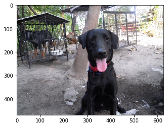

```
Dogs detected! Breed: Labrador_retriever
```

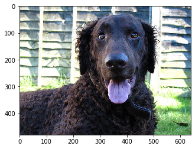

```
Dogs detected! Breed: Curly-coated_retriever
```

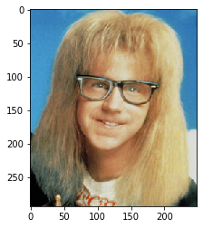

```
Humans detected!!! Resembles to Breed: Poodle :)
```

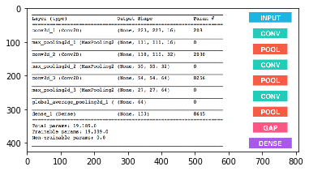

```
Can't Detect either of Dog or Human
```

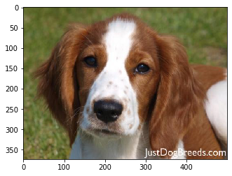

```
Dogs detected! Breed: Irish_red_and_white_setter
```

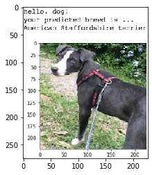

```
Dogs detected! Breed: Great_dane
```

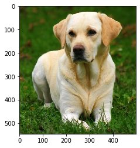

```
Dogs detected! Breed: Labrador_retriever
```

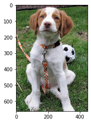

```
Dogs detected! Breed: Brittany
```

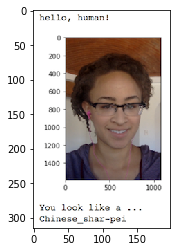

```
Humans detected!!! Resembles to Breed: Brussels_griffon :)
```

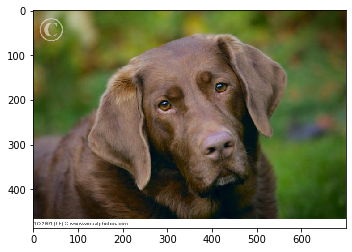

```
Dogs detected! Breed: Labrador_retriever
```

[figure not shown]

```
Dogs detected! Breed: Curly-coated_retriever
```

```python
## TODO: Execute your algorithm from Step 6 on
## at least 6 images on your computer.
## Feel free to use as many code cells as needed.
files, _ = os.walk('./images')
for file in files[2]:
    img_path = os.path.join('./images', file)
    det_algo(img_path)
```

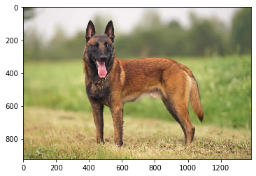

```
Dogs detected! Breed: Belgian_malinois
```

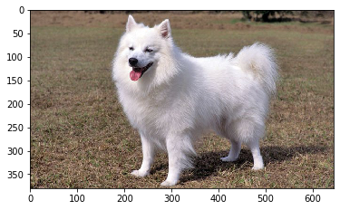

```
Dogs detected! Breed: American_eskimo_dog
```

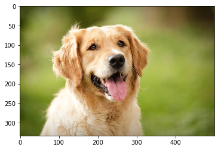

```
Dogs detected! Breed: Golden_retriever
```

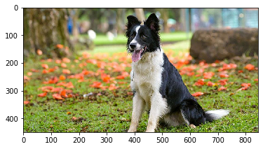

```
Dogs detected! Breed: Canaan_dog
```

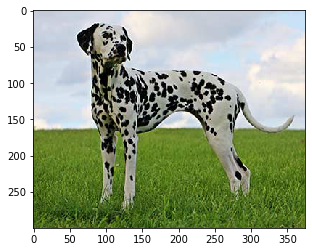

```
Dogs detected! Breed: Dalmatian
```

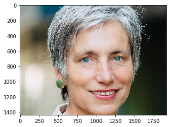

```
Humans detected!!! Resembles to Breed: Italian_greyhound :)
```

[figure not shown]

```
Humans detected!!! Resembles to Breed: Finnish_spitz :)
```

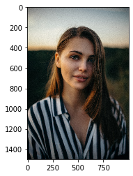

```
Humans detected!!! Resembles to Breed: Havanese :)
```

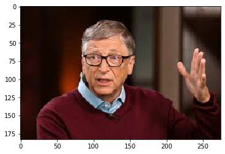

```
Humans detected!!! Resembles to Breed: Dogue_de_bordeaux :)
```

[figure not shown]

```
Humans detected!!! Resembles to Breed: Welsh_springer_spaniel :)
```

```python
files = os.listdir('./test_images')
for file in files:
    img_path = os.path.join('./test_images', file)
    det_algo(img_path)
```